# Seções 2.1 e 2.2 do livro-texto

Este Notebook contém alguns exemplos retirados do livro-texto.

- Seção 2.1 - Estruturas de Dados
- Seção 2.2 - Algoritmos de Busca

## Seção 2.1 Estruturas de Dados

### Sequências

```python
texto = "Aprendendo Python na disciplina de linguagem de programação."
print(f"Tamanho do texto = {len(texto)}")
print(f"Python in texto = {'Python' in texto}")
print(f"Quantidade de y no texto = {texto.count('y')}")
print(f"As 5 primeiras letras são: {texto[0:6]}")
```

```
Tamanho do texto = 60
Python in texto = True
Quantidade de y no texto = 1
As 5 primeiras letras são: Aprend
```

```python
texto = "Aprendendo Python na disciplina de linguagem de programação."
print(texto.upper())
print(texto.replace("i", 'XX'))
```

```
APRENDENDO PYTHON NA DISCIPLINA DE LINGUAGEM DE PROGRAMAÇÃO.
Aprendendo Python na dXXscXXplXXna de lXXnguagem de programação.
```

### Listas

```python
vogais = ['a', 'e', 'i', 'o', 'u']
for vogal in vogais:
    print(f'Posição = {vogais.index(vogal)}, valor = {vogal}')
```

```
Posição = 0, valor = a
Posição = 1, valor = e
Posição = 2, valor = i
Posição = 3, valor = o
Posição = 4, valor = u
```

```python
vogais = []
print(f"Tipo do objeto vogais = {type(vogais)}")
vogais.append('a')
vogais.append('e')
vogais.append('i')
vogais.append('o')
vogais.append('u')
for p, x in enumerate(vogais):
    print(f"Posição = {p}, valor = {x}")
```

```
Tipo do objeto vogais = <class 'list'>
Posição = 0, valor = a
Posição = 1, valor = e
Posição = 2, valor = i
Posição = 3, valor = o
Posição = 4, valor = u
```

```python
frutas = ["maça", "banana", "uva", "mamão", "maça"]
notas = [8.7, 5.2, 10, 3.5]
print("maça" in frutas)  # True
print("abacate" in frutas)  # False
print("abacate" not in frutas)  # True
print(min(frutas))  # banana
print(max(notas))  # 10
print(frutas.count("maça"))  # 2
print(frutas + notas)
print(2 * frutas)
```

```
True
False
True
banana
10
2
['maça', 'banana', 'uva', 'mamão', 'maça', 8.7, 5.2, 10, 3.5]
['maça', 'banana', 'uva', 'mamão', 'maça', 'maça', 'banana', 'uva', 'mamão', 'maça']
```

```python
lista = ['Python', 30.61, "Java", 51, ['a', 'b', 20], "maça"]
print(f"Tamanho da lista = {len(lista)}")
for i, item in enumerate(lista):
    print(f"Posição = {i}, valor = {item} --> tipo"
          f" individual = {type(item)}")
print("\nExemplos de slices:\n")
print("lista[1] = ", lista[1])
print("lista[0:2] = ", lista[0:2])
print("lista[:2] = ", lista[:2])
print("lista[3:5] = ", lista[3:5])
print("lista[3:6] = ", lista[3:6])
print("lista[3:] = ", lista[3:])
print("lista[-2] = ", lista[-2])
print("lista[-1] = ", lista[-1])
print("lista[4][1] = ", lista[4][1])
```

```
Tamanho da lista = 6
Posição = 0, valor = Python --> tipo individual = <class 'str'>
Posição = 1, valor = 30.61 --> tipo individual = <class 'float'>
Posição = 2, valor = Java --> tipo individual = <class 'str'>
Posição = 3, valor = 51 --> tipo individual = <class 'int'>
Posição = 4, valor = ['a', 'b', 20] --> tipo individual = <class 'list'>
Posição = 5, valor = maça --> tipo individual = <class 'str'>

Exemplos de slices:

lista[1] =  30.61
lista[0:2] =  ['Python', 30.61]
lista[:2] =  ['Python', 30.61]
lista[3:5] =  [51, ['a', 'b', 20]]
lista[3:6] =  [51, ['a', 'b', 20], 'maça']
lista[3:] =  [51, ['a', 'b', 20], 'maça']
lista[-2] =  ['a', 'b', 20]
lista[-1] =  maça
lista[4][1] =  b
```

### map()

```python
linguagens = 'Python Java JavaScript C C# C++ Swift Go Kotlin'.split()
```

```python
linguagens
```

```
['Python', 'Java', 'JavaScript', 'C', 'C#', 'C++', 'Swift', 'Go', 'Kotlin']
```

```python
nova_lista = map(lambda x: x.lower(), linguagens)
```

```python
nova_lista
```

```
<map at 0x7d4397086b30>
```

```python
list(nova_lista)
```

```
['python', 'java', 'javascript', 'c', 'c#', 'c++', 'swift', 'go', 'kotlin']
```

Outro exemplo

```python
def evaluate(x):
    print(x)

mymap = map(evaluate, [1,2,3]) # não imprime nada ainda
print(mymap)
```

```
<map object at 0x7d4397086080>
```

next() retorna o próximo item de um iterador

```python
next(mymap)
```

```
1
```

```python
next(mymap)
next(mymap)
next(mymap)
```

```
2
3
```

```
---------------------------------------------------------------------------
StopIteration                             Traceback (most recent call last)
<ipython-input-30-4bd46ba7f6f8> in <cell line: 3>()
      1 next(mymap)
      2 next(mymap)
----> 3 next(mymap)

StopIteration:
```

### filter()

```python
num = list(range(21))
```

```python
num
```

```
[0, 1, 2, 3, 4, 5, 6, 7, 8, 9, 10, 11, 12, 13, 14, 15, 16, 17, 18, 19, 20]
```

```python
a = filter(lambda x: x % 2 == 0, num)
a
```

```
<filter at 0x7d4364532110>
```

```python
list(a)
```

```
[0, 2, 4, 6, 8, 10, 12, 14, 16, 18, 20]
```

## Tuplas

- Tuplas são imutáveis

```python
tupla01 = ()  # tupla vazia
tupla01
```

```
()
```

```python
tupla01 = (1, 2, 3)
tupla01
```

```
(1, 2, 3)
```

```python
vogais = ('a', 'e', 'i', 'o', 'u')
```

enumerate() : qdo precisamos de um contador e um valor

```python
 for p, x in enumerate(vogais) :
    print(p, x)
```

```
0 a
1 e
2 i
3 o
4 u
```

## Set

- Armazena vários itens em uma única variável
- Não permite itens duplicados, não é ordenado, não é indexado, não pode ser alterado (porém pode ser eliminado ou adicionado)

```python
 set1 = {'a', 'b', 'c'}
 set1
```

```
{'a', 'b', 'c'}
```

```python
set1.add('a')
set1
```

```
{'a', 'b', 'c'}
```

```python
set1 = set(['a', 'b', 'c'])
```

```python
set1
```

```
{'a', 'b', 'c'}
```

### Dicionário

- Pode ser alterado, não pode duplicado.

```python
thisdict = {
  "brand": "Ford",
  "model": "Mustang",
  "year": 1964
}
```

```python
thisdict
```

```
{'brand': 'Ford', 'model': 'Mustang', 'year': 1964}
```

```python
thisdict['model']
```

```
'Mustang'
```

### Array NumPy

- NumPy é uma bilbioteca para computação científica, bastante utilizada.

```python
import numpy as np

matriz = np.array([[1, 2], [3, 4]])
```

```python
matriz
```

```
array([[1, 2],
       [3, 4]])
```

```python
np.zeros((3, 3))
```

```
array([[0., 0., 0.],
       [0., 0., 0.],
       [0., 0., 0.]])
```

```python
np.ones((2,2))
```

```
array([[1., 1.],
       [1., 1.]])
```

```python
np.eye(4)    # matriz identidade
```

```
array([[1., 0., 0., 0.],
       [0., 1., 0., 0.],
       [0., 0., 1., 0.],
       [0., 0., 0., 1.]])
```

```python
np.eye(4).sum()  # também: min, máx, mean
```

```
4.0
```

```python
np.ones((1,5))
```

```
array([[1., 1., 1., 1., 1.]])
```

```python
numpy.ones((1,5)).reshape(5,1)
```

[output not shown]

### Biblioteca Pandas (introdução)

```python
import pandas as pd
```

```python
mydataset = {
  'carros': ["BMW", "Volvo", "Ford"],
  'passageiros': [3, 7, 2]
}
```

```python
mydataset
```

```
{'carros': ['BMW', 'Volvo', 'Ford'], 'passageiros': [3, 7, 2]}
```

```python
myvar = pd.DataFrame(mydataset)
```

```python
myvar
```

|  | carros | passageiros |
| --- | --- | --- |
| 0 | BMW | 3 |
| 1 | Volvo | 7 |
| 2 | Ford | 2 |

```python
a = pd.Series([1, 7, 2])
a
```

```
0    1
1    7
2    2
dtype: int64
```

```python
a[0]
```

```
1
```

```python
a = [1, 7, 2]
myvar = pd.Series(a, index = ["x", "y", "z"])
myvar
```

```
x    1
y    7
z    2
dtype: int64
```

```python
myvar['y']
```

```
7
```

```python
myvar.info()
```

[output not shown]

## Seção 2.2 - Algoritmos de Busca

### Busca sequencial

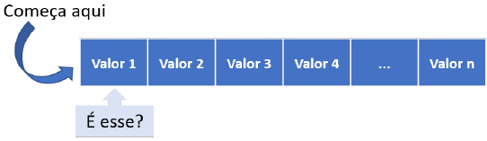

```python
lista = [52, 73, 95, 98, 99, 103, 123, 152, 158, 173]
procuro = 98
for i,v in enumerate(lista) :
    if v == procuro :
        print("Achei!", i, v)
```

```
Achei! 3 98
```

### Busca binária

Os valores precisam estar ordenados.

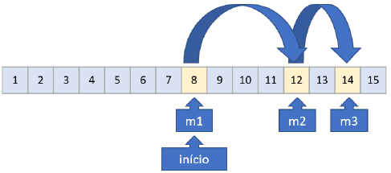

A primeira coisa é ordenar a lista:

```python
achar = 152
lista = sorted([ 103, 123, 152, 158, 173, 52, 73, 95, 98, 99])
lista
```

```
[52, 73, 95, 98, 99, 103, 123, 152, 158, 173]
```

A lista tem 10 números, vamos divir em 2, e iniciar em ~ 5:

```python
i = 5
lista[i]
```

```
103
```

```python
achar > lista[i]
```

```
True
```

O número que queremos achar está entre 5 e 10, vamos dividir por 2 de novo, e pegar ~ 7

```python
i = 7
achar > lista[i]
```

```
False
```

Ele não é maior que o valor da lista[7], vamos verificar se é menor:

```python
achar < lista[i]
```

```
False
```

Ele também não é menor. Se fosse menor poderíamos dividir o intervalo de novo por dois.

Neste caso como não é maior nem menor, então só pode ser igual, ou seja, encontramos o número.

## Exercício

Melhorar o algoritmo acima, deixar ele mais automatizado. Exemplo de solução possível:

```python
achar = 123
lista = sorted([ 103, 123, 152, 158, 173, 52, 73, 95, 98, 99])
lista
```

```
[52, 73, 95, 98, 99, 103, 123, 152, 158, 173]
```

```python
l = len(lista)
i = int(l//2)
```

```python
while True :
    if achar == lista[i] :
        print("Achei!", i)
        break
    if achar > lista[i] :
        i = (l - i)//2 + i
    else :
        i = i // 2
```

```
Achei! 6
```